# Urosalpinx growth rate (length)

Andrew Villeneuve

5/26/2020

# The Study

For this part of the study, we measured growth rates of juvenile snails. We measured snails within two days of them hatching, and grew them in tea strainers separated by population for 24 days. Nine replicates per population were distributed in six temperatures, with three groups of three subreplicates in each temperature/population treatment. The end length was recorded, and we substracted the starting length from the beginning length to get the growth rate (over 24 days).

# Metadata

- code
  - Unique code for each indiviudal snail, corresponding to population, temperature treatment. First digit = temperature (1=16,2=20,3=24,4=26, 5=28, 6=30), second digit = site (1=Willapa, 2=Humboldt, 3=Great Bay, 4=Woods Hole, 5=Oyster, 6=Beaufort, 7=Folly Beach, 8=Skidaway), third digit = tupperware bin number (1-3), fourth digit = snail replicate (1-3)
- pop
  - Source population of each snail. See data table below for list of site abbreivations with site.
- temp
  - Common garden temperature the snails were raised in for 24 days. Degrees C
- hatch
  - hatch date of each snail from it’s egg case (m/dd/yyyy)
- exp.date
  - Date on which hatchling snails were placed in the common garden experiment. Not more then 2 days from the hatch date. (m/dd/yyyy)
- grow.date
  - End date where growth measurements were taken. 24 days after exp.date, therefore no more then 26 days post hatch (m/dd/yyyy)
- alive
  - Tracks if snails survived the experient. m marks missing, n marks no, y marks yes
- rem.oysters
  - Was there a surplus of food at the end of the experiment? n marks no, y marks yes
- cal.length.start
  - caliper length of hatchlings upon entering the experment. We took photos of snails before entering snails into the experiment, and then used ImageJ to extract snail sizes. Size in mm
- cal.length.end
  - caliper length of hatchling at the end of the experiemnt. We took caliper measurements of the snails, as well as verifying the measurements using a subset of photographs in ImageJ. Size in mm
- wt
  - End weight of snail. Note that no initial starting weight was recorded. Weight in g.
- ran.out
  - Did the snail ever run out of food during the consumption experiment? 1 for yes, 0 for no
- bin
  - Bin number, controls subreplication. The third digit of the code.
- oce
  - Ocean (Atlantic or Pacific)

```
##   site.abbreviation            site
## 1               gbj   Great Bay, NH
## 2                wh  Woods Hole, MA
## 3                oy      Oyster, VA
## 4                bf    Beaufort, NC
## 5                fb Folly Beach, SC
## 6              gcsk    Skidaway, GA
## 7           nah1516     Willapa, WA
## 8              hmi2    Humboldt, CA
```

# Data Setup

We had to clean parts of the data to prepare it for analysis. The first issue we had to resolve was the extreme weight and caliper length outliers, which was clearly due to a misplaced decimal or missing 0 during data entry. In the silenced part of the markdown, this had to be corrected 5/432 times.

The second issue was that some snails ran out of food during the growth experiment, which could jeopardize our assumption of unlimited growth while in the common garden experiment. The vast majority (391/432) of snails never ran out of food. 40/432 ran out of food once, while 1/432 ran out of food twice. For the purposes of this experiment, we decided to include snails that missed a single meal during the entirity of the experiment, but removed the single case in which a snail ran out food twice.

The third issue was that some snails died, or went missing or were crushed, over the course of the experiment. We removed these snails from consideration at the timepoint they died or went missing.

## Environmental Data

We extracted temperature data from each site. With this data, we calculated different environmental predictors that might explain patterns in growth.

We also used latitude as a predictor (not shown in table below)

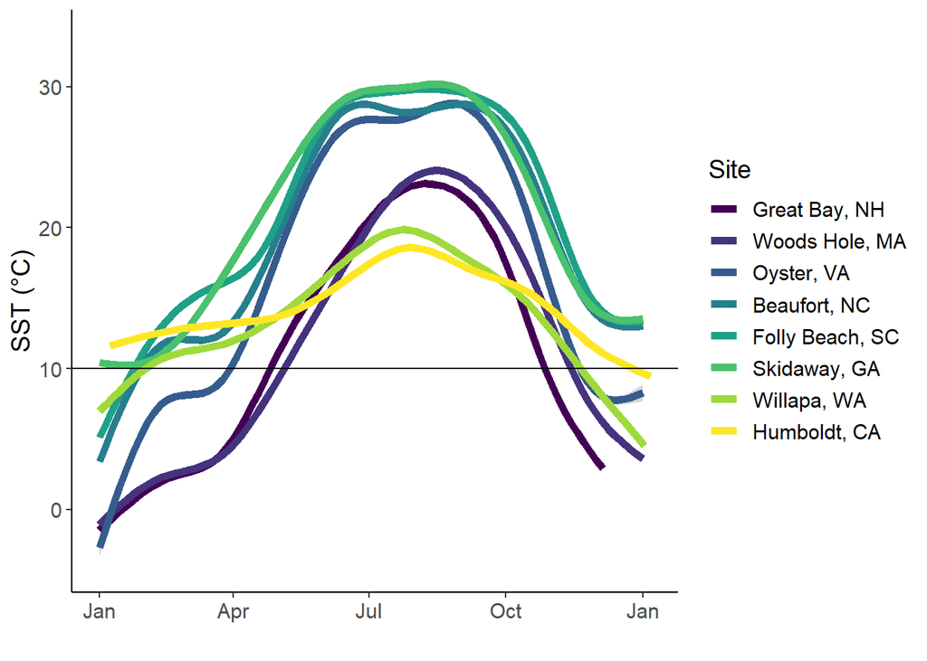

```
##      site quantile   decile      max     mean summer.mean seasonlength10
## 1     gbj 22.91100 23.69700 25.96300 12.40097    20.88969              1
## 2      wh 23.60000 24.30000 26.00000 12.10044    21.35360              1
## 3      oy 28.92496 30.07281 33.56934 17.08424    27.54020              1
## 4      bf 29.10000 29.80000 31.00000 19.73769    28.28414              1
## 5      fb 29.80000 30.00000 31.30000 20.34944    29.12126              1
## 6 nah1516 19.80700 20.43960 26.49120 13.91728    18.73544              1
## 7    hmi2 18.77000 19.78000 21.80000 14.43312    17.36318              1
## 8     to3 22.14730 22.71100 24.12180 17.90621    20.91789              1
## 9    gcsk 30.26200 30.97800 33.47800 21.45739    29.36123              1
##   seasonlength16
## 1              0
## 2              0
## 3              1
## 4              1
## 5              1
## 6              0
## 7              0
## 8              1
## 9              1
```

# Data exploration

## Do sites differ?

Do populations differ in their growth rate? Here, ANOVA tells us that growth betwween sites are signficantly different.

```r
anovasites<-(aov(cal.length~pop*temp,data=growth.alive))
summary(anovasites)
```

```
##              Df Sum Sq Mean Sq F value   Pr(>F)
## pop           7   22.9     3.3   7.146 4.99e-08 ***
## temp          1  352.0   352.0 769.916  < 2e-16 ***
## pop:temp      7   10.8     1.5   3.379  0.00165 **
## Residuals   373  170.5     0.5
## ---
## Signif. codes:  0 '***' 0.001 '**' 0.01 '*' 0.05 '.' 0.1 ' ' 1
```

```r
growth.alive$pop<-as.factor(growth.alive$pop)
```

## Shell size by population

```
##              Df Sum Sq Mean Sq F value   Pr(>F)
## pop           7  2.149 0.30700   8.549 9.69e-10 ***
## Residuals   381 13.682 0.03591
## ---
## Signif. codes:  0 '***' 0.001 '**' 0.01 '*' 0.05 '.' 0.1 ' ' 1
```

## Correlations

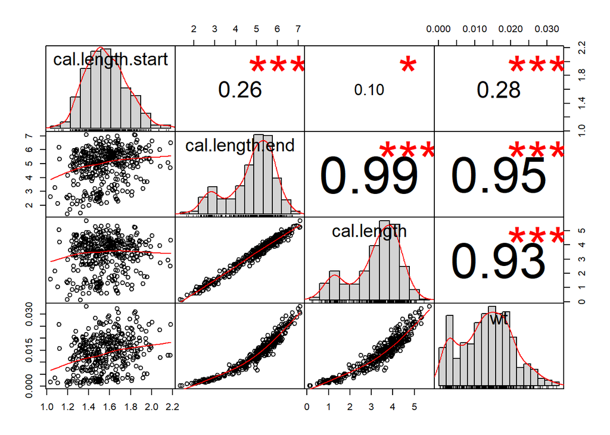

Here, we see that cal length and weight are both highly correlated. Thus, we will not include weight in any of our models.

## Residuals of full model

Here, we investigate the residuals of the full model.

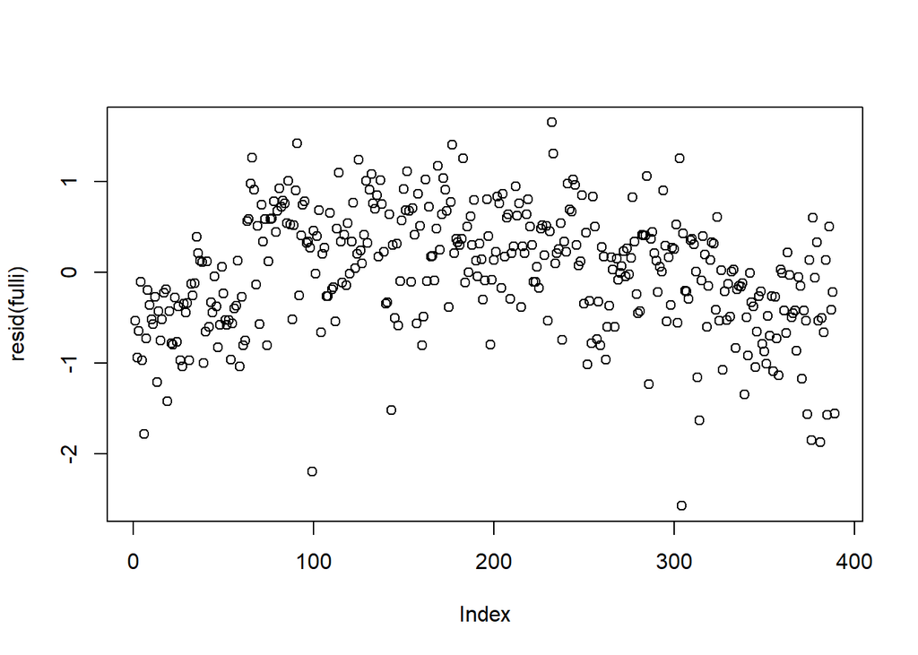

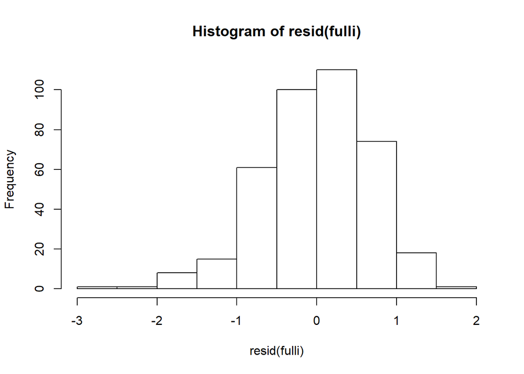

```
## [1] -0.751374
```

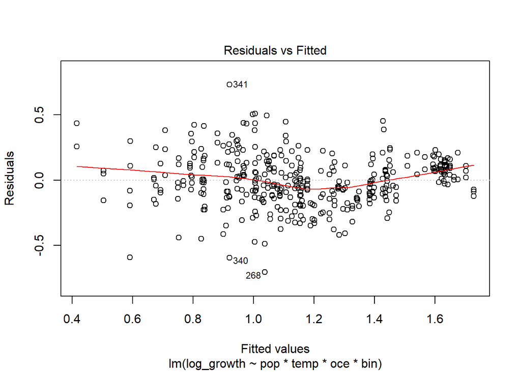

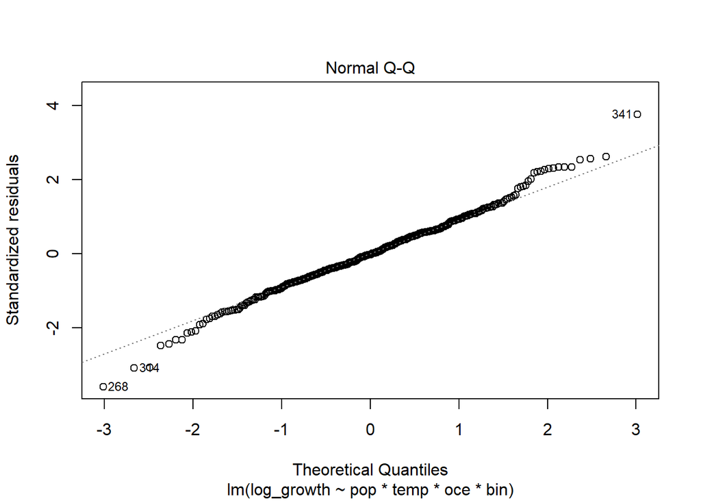

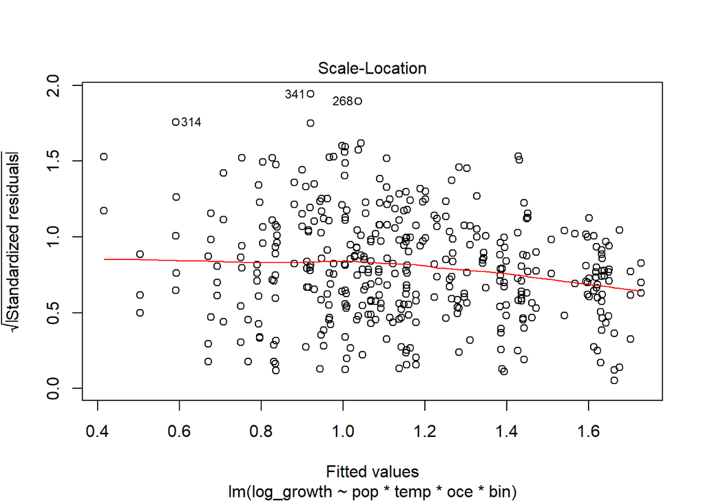

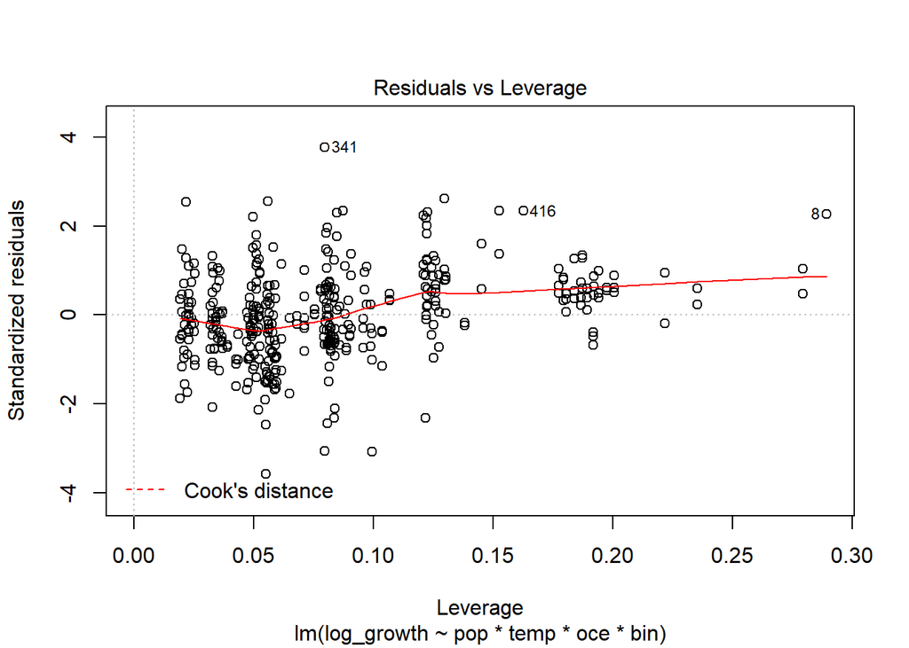

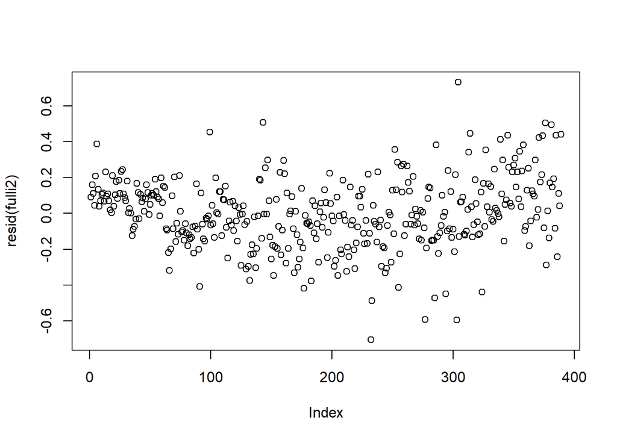

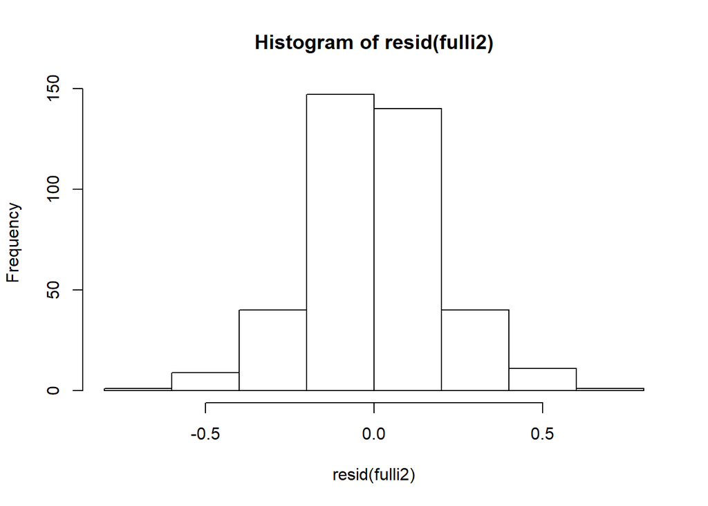

```
## [1] 0.04621708
```

## Coplots

Other than temperature and population, which we control for, do we see different reactions depending on bin? Here, reactions appaer to be the same no matter what bin we used. Note: Margins were too big on this figure to include in the markdown - viewable in R console.

# Data Analysis

## Model predictors

We are going to create TPCs for each population by temperature, using both piecewise (segmented) regression and quadratic regression. What predictors should be used in these models?

```
##
## Model selection based on AICc:
##
##                   K    AICc Delta_AICc AICcWt Cum.Wt      LL
## pop*temp         17  818.79       0.00   0.30   0.30 -391.57
## pop*temp*oce     17  818.79       0.00   0.30   0.60 -391.57
## pop*temp*out     32  819.66       0.87   0.19   0.79 -374.86
## pop*temp*oce*out 32  819.66       0.87   0.19   0.98 -374.86
## pop.temp         10  827.64       8.85   0.00   0.99 -403.53
## pop.temp.oce     10  827.64       8.85   0.00   0.99 -403.53
## pop.temp.bin     11  828.45       9.66   0.00   0.99 -402.87
## pop.temp.oce.bin 11  828.45       9.66   0.00   1.00 -402.87
## pop.temp.out     11  829.75      10.96   0.00   1.00 -403.53
## pop.temp.oce.out 11  829.75      10.96   0.00   1.00 -403.53
## fulla            12  830.57      11.78   0.00   1.00 -402.87
## temp*out          5  832.21      13.42   0.00   1.00 -411.02
## bin*out*temp      9  836.37      17.58   0.00   1.00 -408.95
## oce*temp*out      9  838.90      20.11   0.00   1.00 -410.21
## pop*temp*bin     33  843.43      24.63   0.00   1.00 -385.55
## pop*temp*oce*bin 33  843.43      24.63   0.00   1.00 -385.55
## temp*oce*bin*out 17  849.14      30.34   0.00   1.00 -406.74
## temp              3  851.53      32.74   0.00   1.00 -422.73
## oce               3  851.53      32.74   0.00   1.00 -422.73
## temp.bin          4  852.64      33.85   0.00   1.00 -422.27
## temp.out          4  853.46      34.67   0.00   1.00 -422.68
## temp.oce          4  853.57      34.78   0.00   1.00 -422.73
## temp*bin          5  854.53      35.74   0.00   1.00 -422.19
## bin.out.temp      5  854.54      35.75   0.00   1.00 -422.19
## oce.temp.bin      5  854.69      35.90   0.00   1.00 -422.27
## temp*oce          5  855.35      36.56   0.00   1.00 -422.60
## oce.temp.out      5  855.51      36.72   0.00   1.00 -422.68
## temp.oce.bin.out  6  856.60      37.81   0.00   1.00 -422.19
## fulli            56  859.66      40.87   0.00   1.00 -364.22
## oce*temp*bin      9  860.69      41.90   0.00   1.00 -421.11
## pop.out          10 1234.93     416.14   0.00   1.00 -607.17
## out               3 1238.40     419.61   0.00   1.00 -616.17
## bin.out           4 1240.11     421.32   0.00   1.00 -616.01
## oce.out           4 1240.22     421.43   0.00   1.00 -616.06
## bin*out           5 1241.56     422.77   0.00   1.00 -615.70
## oce.bin.out       5 1241.94     423.15   0.00   1.00 -615.89
## oce*out           5 1242.26     423.47   0.00   1.00 -616.05
## pop               9 1245.17     426.38   0.00   1.00 -613.35
## pop.oce           9 1245.17     426.38   0.00   1.00 -613.35
## pop*oce           9 1245.17     426.38   0.00   1.00 -613.35
## pop.bin          10 1246.57     427.77   0.00   1.00 -612.99
## null              2 1247.06     428.27   0.00   1.00 -621.51
## oce*bin*out       9 1247.99     429.20   0.00   1.00 -614.76
## pop*out          17 1248.47     429.68   0.00   1.00 -606.41
## bin               3 1248.51     429.72   0.00   1.00 -621.23
## oce.bin           4 1250.50     431.71   0.00   1.00 -621.20
## oce*bin           5 1251.30     432.51   0.00   1.00 -620.57
## pop*bin          17 1258.50     439.71   0.00   1.00 -611.43
```

Here, we see that a few models are well supported. We choose the interactive pop*temp model only because 1) the additive model only tells us if populations are different at each temperature, while the additive model also tells us the populations slopes with temperature and gives us a TPC 2) oce adds nothing to the models, so is removed. 3) Looking at our coplots of bin, bin had no effect on growth.

```
##
## Call:
## lm(formula = cal.length ~ pop * temp, data = growth.alive)
##
## Residuals:
##      Min       1Q   Median       3Q      Max
## -2.66991 -0.40284  0.01743  0.45983  1.57275
##
## Coefficients:
##                     Estimate Std. Error t value Pr(>|t|)
## (Intercept)         -1.77328    0.49439  -3.587 0.000379 ***
## popFolly Beach       0.53984    0.70688   0.764 0.445534
## popGreat Bay        -1.03615    0.72091  -1.437 0.151474
## popHumboldt          0.39919    0.69918   0.571 0.568388
## popOyster           -0.45481    0.69108  -0.658 0.510872
## popSkidaway          0.63587    0.68547   0.928 0.354197
## popWillapa           0.48179    0.72793   0.662 0.508471
## popWoods Hole        1.45221    0.72244   2.010 0.045136 *
## temp                 0.21233    0.02004  10.593  < 2e-16 ***
## popFolly Beach:temp -0.03559    0.02881  -1.235 0.217443
## popGreat Bay:temp    0.05826    0.02931   1.988 0.047558 *
## popHumboldt:temp    -0.02477    0.02843  -0.871 0.384250
## popOyster:temp       0.02420    0.02805   0.863 0.388910
## popSkidaway:temp    -0.03873    0.02793  -1.386 0.166441
## popWillapa:temp     -0.01411    0.02932  -0.481 0.630791
## popWoods Hole:temp  -0.06146    0.02910  -2.112 0.035343 *
## ---
## Signif. codes:  0 '***' 0.001 '**' 0.01 '*' 0.05 '.' 0.1 ' ' 1
##
## Residual standard error: 0.6762 on 373 degrees of freedom
## Multiple R-squared:  0.6934, Adjusted R-squared:  0.6811
## F-statistic: 56.24 on 15 and 373 DF,  p-value: < 2.2e-16
```

## Broken Stick regression

It’s hard to compare TPC against one another. One method we’ve settled on is the use of broken stick regression to allow us to quantify the shape of the reaction as well as the thermal optima (x) and the maximal trait performance (y). Here, we used the segmented package to create single-optima broken stick regressions that also allow us to extract optimas

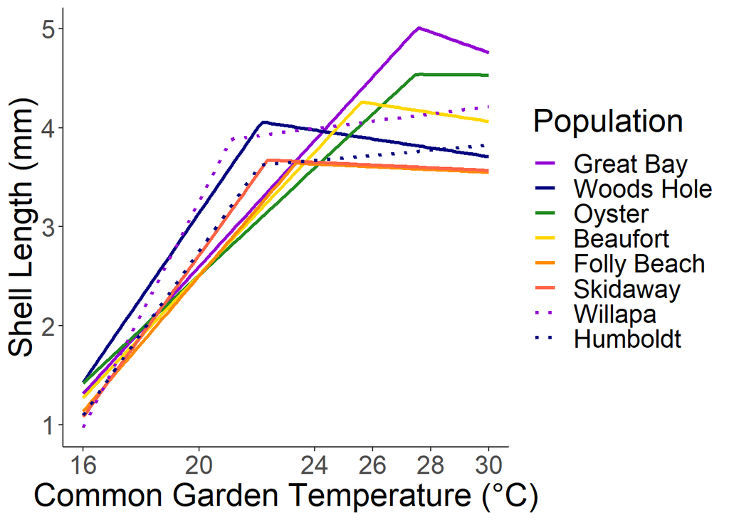

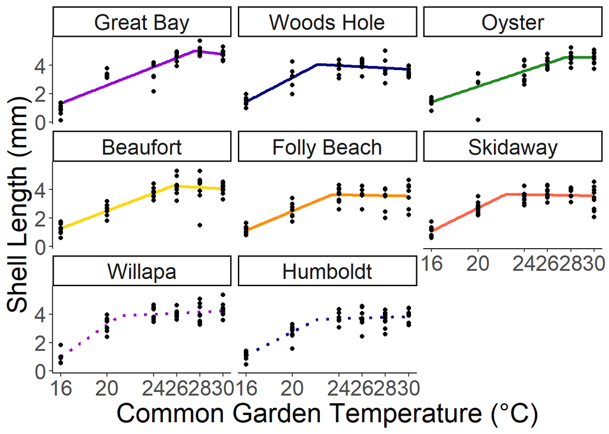

*P-score: The P-score tests the null hypothesis for no difference in slopes, i.e. no breakpoint. If P is below 0.05, then there is a breakpoint. We see here that all p-scores are signficant, and thus breakpoints do exist in our data

- Davies test: we perform this analysis, but is less powerful for one breakpoint analyses. I am not certain what this means, since the null hypothesis is no breakpoint but we get radically different results this way.
- CI Low/High: Confidence interval of the breakpoint
- Breakpoint: Breakpoint

```
##          site      P.Score  Davies.Test  CI.Low CI.High breakpoint
## 1   Great Bay 2.044438e-04 0.0007133133 26.0458 29.0785    27.5622
## 2  Woods Hole 1.355661e-10 0.4191475386 20.3966 23.9135    22.1550
## 3      Oyster 3.418056e-02 0.8691763589 25.1749 29.7494    27.4621
## 4    Beaufort 6.195021e-05 0.8964569173 23.7413 27.4960    25.6186
## 5 Folly Beach 9.908718e-06 0.8001403394 20.6380 26.0520    23.3450
## 6    Skidaway 2.705474e-10 0.1706811552 20.6209 24.1080    22.3644
## 7     Willapa 1.695057e-10 0.5011343864 19.8379 22.3878    21.1129
## 8    Humboldt 1.747966e-07 0.5606387987 20.2784 23.9175    22.0979
```

## Breakpoint analysis

To be able to complete statistical analysis of the differences in TPC curves, I extracted the x and y componenets of each curve to give me the thermal optima and maximal trait performance, respectively.

### Maximum trait Performance (y axis)

```
##
## Model selection based on AICc:
##
##                  K  AICc Delta_AICc AICcWt Cum.Wt    LL
## nullo            2 16.81       0.00   0.36   0.36 -5.20
## seasonlength10   2 16.81       0.00   0.36   0.72 -5.20
## seasonlengtho10  3 20.90       4.09   0.05   0.76 -4.45
## o*seasonlength10 3 20.90       4.09   0.05   0.81 -4.45
## lat              3 21.61       4.80   0.03   0.84 -4.81
## mean             3 22.18       5.37   0.02   0.86 -5.09
## seasonlength16   3 22.28       5.47   0.02   0.89 -5.14
## s.mean           3 22.39       5.58   0.02   0.91 -5.20
## omax             3 22.39       5.58   0.02   0.93 -5.20
## t.mean           3 22.40       5.59   0.02   0.95 -5.20
## q.mean           3 22.41       5.60   0.02   0.98 -5.20
## lato             4 23.24       6.43   0.01   0.99 -0.95
## q.meano          4 26.78       9.97   0.00   0.99 -2.72
## s.meano          4 26.83      10.02   0.00   0.99 -2.75
## t.meano          4 27.35      10.54   0.00   1.00 -3.01
## seasonlengtho16  4 28.02      11.21   0.00   1.00 -3.34
## seasonlength16   4 28.02      11.21   0.00   1.00 -3.34
## maxo             4 29.27      12.46   0.00   1.00 -3.97
## meano            4 29.96      13.15   0.00   1.00 -4.31
## o*lat            5 41.60      24.79   0.00   1.00 -0.80
## o*q.mean         5 44.83      28.02   0.00   1.00 -2.42
## o*s.mean         5 44.85      28.04   0.00   1.00 -2.43
## o*t.mean         5 45.57      28.76   0.00   1.00 -2.79
## o*max            5 46.97      30.16   0.00   1.00 -3.48
## o*mean           5 48.43      31.63   0.00   1.00 -4.22
```

Here, it appears that the season length as calculated at 10C is the best predictor. This is followed by latitude and season length calculated at 16C. latitude doesn’t tell us much about the environment, so let’s take a look at how both season length metrics we calculated perform when calculating maximal trait performance.

```r
##Maximal trait performance (y)

brkptym<-(lm(brkpty~seasonlength16,brkpts))
summary(brkptym)
```

```
##
## Call:
## lm(formula = brkpty ~ seasonlength16, data = brkpts)
##
## Residuals:
##     Min      1Q  Median      3Q     Max
## -0.5250 -0.3629 -0.1719  0.3015  0.8688
##
## Coefficients:
##                Estimate Std. Error t value Pr(>|t|)
## (Intercept)      4.1452     0.2656  15.606 4.38e-06 ***
## seasonlength16  -0.1169     0.3756  -0.311    0.766
## ---
## Signif. codes:  0 '***' 0.001 '**' 0.01 '*' 0.05 '.' 0.1 ' ' 1
##
## Residual standard error: 0.5312 on 6 degrees of freedom
## Multiple R-squared:  0.01588,    Adjusted R-squared:  -0.1481
## F-statistic: 0.09684 on 1 and 6 DF,  p-value: 0.7662
```

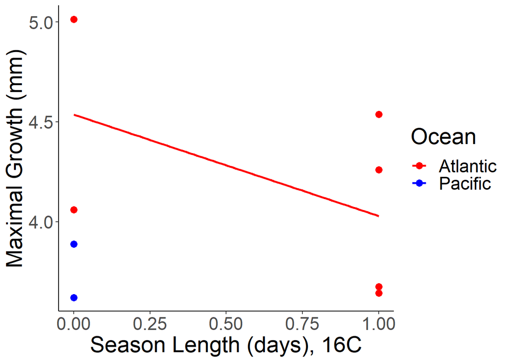

```r
ggplot(brkpts,aes(x=seasonlength16,y=brkpty,color=oce,fill=oce),group=oce)+
  geom_point(size=3)+theme_classic()+
  ylab("Maximal Growth (mm)")+
  xlab("Season Length (days), 16C")+
  theme(text=element_text(family="arial",size=22))+
    scale_color_manual(labels=c("Atlantic","Pacific"),name="Ocean", values=c('red','blue'))+
    scale_fill_manual(labels=c("Atlantic","Pacific"),name="Ocean", values=c('red','blue'))+
  geom_smooth(method='lm',se=F)
```

```r
brkptym2<-(lm(brkpty~lat,brkpts))
summary(brkptym2)
```

```
##
## Call:
## lm(formula = brkpty ~ lat, data = brkpts)
##
## Residuals:
##     Min      1Q  Median      3Q     Max
## -0.5323 -0.3115 -0.1674  0.3352  0.7961
##
## Coefficients:
##             Estimate Std. Error t value Pr(>|t|)
## (Intercept)  2.96116    1.43137   2.069    0.084 .
## lat          0.02917    0.03679   0.793    0.458
## ---
## Signif. codes:  0 '***' 0.001 '**' 0.01 '*' 0.05 '.' 0.1 ' ' 1
##
## Residual standard error: 0.5095 on 6 degrees of freedom
## Multiple R-squared:  0.0948, Adjusted R-squared:  -0.05606
## F-statistic: 0.6284 on 1 and 6 DF,  p-value: 0.4581
```

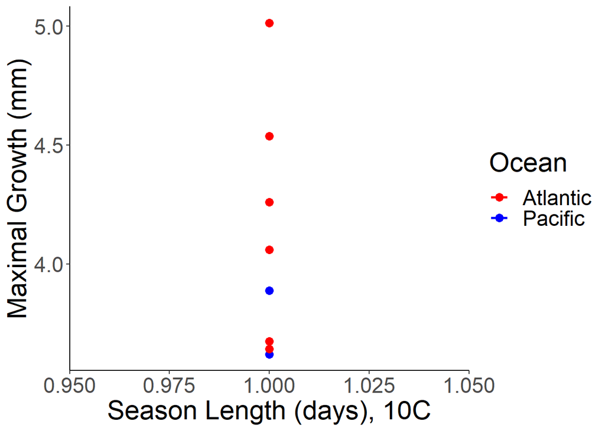

```r
ggplot(brkpts,aes(x=seasonlength10,y=brkpty,color=oce,fill=oce),group=oce)+
  geom_point(size=3)+theme_classic()+
  ylab("Maximal Growth (mm)")+
  xlab("Season Length (days), 10C")+
  theme(text=element_text(family="arial",size=22))+
    scale_color_manual(labels=c("Atlantic","Pacific"),name="Ocean", values=c('red','blue'))+
    scale_fill_manual(labels=c("Atlantic","Pacific"),name="Ocean", values=c('red','blue'))+
  geom_smooth(method='lm',se=F)
```

But what about the thermal optima?